# Central Limit Theorem

## Uniform Distribution

Let us take a look at a simple example of the central limit theorem. The sample means $X_N=\sum_{i=1}^Nx_i/N$ are generated using a random number generator, which draws $N$ independent numbers $x_1,x_2,\dots,x_N$ between $a$ and $b$ from a uniform probability distribution $$P(x)=\frac{1}{b-a}$$. The mean value of random variable $x$ is $\mu=(a+b)/2$ and its variance is $\sigma=(b-a)/2\sqrt3$. It is easy to see that as the sample size increases the tails become thinner and the histogram becomes more concentrated around the mean. Moreover, the distribution of the sample mean is well approximated by a normal distribution with mean $\mu$ and variance $\sigma/\sqrt{N}$ (red line).

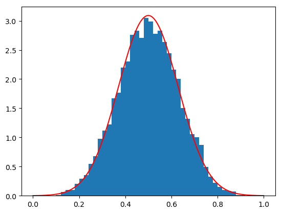

```
1-element Array{Any,1}:
 PyObject <matplotlib.lines.Line2D object at 0x7fb5440ba990>
```

```julia
using PyPlot
using Distributions

N = 5                         # number of terms in sum X_N (sample size)
length = 10000                # number of trials
X_N = Array(Float64, length)  # array with realizations of random variable X_N

a = 0                         # lower bound
b = 1                         # upper bound

d = Uniform(a,b)              # uniform distribution over [a,b]

for i in 1:length
    x_i = rand(d, N)          # N realizations of random variable x
    X_N[i] = sum(x_i)/N       # mean value of x over N realizations
end

x1 = linspace(a, b, 1000)
d1 = Normal((a+b)/2,(b-a)/(2*sqrt(3)*sqrt(N)))
y1 = pdf(d1,x1)

PyPlot.plt[:hist](X_N, bins = 50, range=(a,b), normed=1)
PyPlot.plot(x1,y1,"r")
```

## Gaussian Distribution

This example demonstrates that the mean value of independent and identically distributed Gaussian variables is also a Gaussian variable. In other words, for Gaussian distribution the central limit theorem is valid for any sample size.

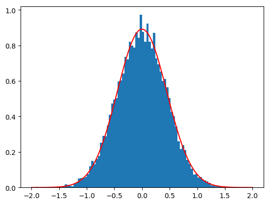

```
1-element Array{Any,1}:
 PyObject <matplotlib.lines.Line2D object at 0x7ff689ac38d0>
```

```julia
using PyPlot
using Distributions

N = 5                         # number of terms in X_N (sample size)
length = 10000                # number of trials
X_N = Array(Float64, length)  # realization of random variable X_N

mu = 0.0                      # \mu - mean value
sigma = 1.0                   # \sigma - variance

d = Normal(mu,sigma)          # normal distribution with mean value \mu and variance \sigma

for i in 1:length
    x_i = rand(d, N)          # N realizations of random variable x
    X_N[i] = sum(x_i)/N       # mean value of x over N realizations
end

x1 = linspace(-2*sigma, 2*sigma, 1000)
d1 = Normal(mu,sigma/sqrt(N))
y1 = pdf(d1,x1)

PyPlot.plt[:hist](X_N, bins = 100, range=(-2*sigma,2*sigma), normed=1)
PyPlot.plot(x1,y1,"r")
```

## Cauchy Distribution

For the Cauchy distribution $$P(x)=\frac{\gamma}{\pi}\frac{1}{(x-\mu)^2+\gamma^2}$$ the central limit theorem is violated. As it is explained in recitation notes, the formal reason for this is the infinite variance of the Cauchy distribution. Check that for any sample size $N$ the sample mean $X_N=\sum_{i=1}^Nx_i/N$ is Cauchy-distributed with exactly the same width parameter $\gamma$.

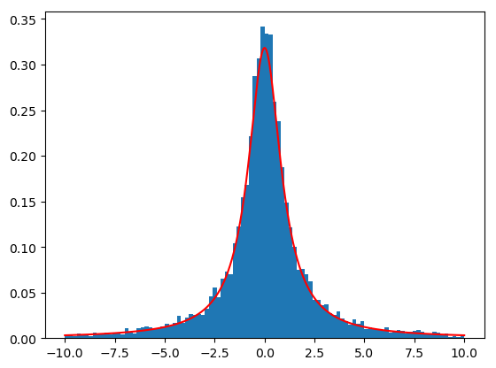

```
1-element Array{Any,1}:
 PyObject <matplotlib.lines.Line2D object at 0x7f9c80ef5990>
```

```julia
using PyPlot
using Distributions

N = 5                         # number of terms in sum X_N (sample size)
length = 10000                # number of trials
X_N = Array(Float64, length)  # array with realizations of random variable X_N

mu = 0.0                      # \mu - mean value
gamma = 1.0                   # \gamma -  scale parameter of Cauchy distribution

d = Cauchy(mu,gamma)

for i in 1:length
    x_i = rand(d, N)          # generation of x_i
    X_N[i] = sum(x_i)/N       # mean value of x over N realizations
end

x1 = linspace(mu-10*gamma, mu+10*gamma, 1000)
d1 = Cauchy(mu,gamma)
y1 = pdf(d1,x1)

PyPlot.plt[:hist](X_N, bins = 100, range=(mu-10*gamma,mu+10*gamma), normed=1)
PyPlot.plot(x1,y1,"r")
```